# Mini git tutorial 1 - getting the Campbell Lab started

Amy Bauer

5/9/2022

*This mini workflow assumes you already have*

*1. wsl installed on your Windows computer. You can install wsl by opening PowerShell and running `wsl --install`. For more information, see https://docs.microsoft.com/en-us/windows/wsl/setup/environment*

*2. git installed on your computer - for more information, see https://git-scm.com/downloads*

*3. a chosen directory that you want to work inside (e.g., a ‘GitHub’ folder)*

*If this is not the case, do this before getting started here.*

# Get ready on our Windows Computers

### Open wsl and some basics

We start by opening the Windows Subsystem for Linux (wsl) on our computer. Wsl allows us to run a Linux environment directly on our Windows system, without having to use a traditional virtual machine or dualboot setup.

We can access wsl by using the **search** tool, entering **wsl**.

To access your Windows PC’s files, wsl mounts drives or other removable disks to the system (think of it as inserting a USB drive). We can change mounts easily by using `/mnt/`. After running wsl, it mounts to the Windows system by default, but you can mount any drive that your Windows PC recognizes. We then change the mounted location to the GitHub folder/repository that we want to work in.

```
cd /mnt/[filepath]                                # cd : change directory
cd /mnt/c/Users/amely/OneDrive/Documents/GitHub   # example path

mkdir [directoryname]                             # make a new directory within your current working directory

# to move between folders:
cd [foldername]                                   # move downstream into a directory
cd ..                                             # navigate up one directory level
cd -                                              # navigate to previous directory (go back)
```

### Create and add a SSH key

Next, we want to create a SSH key and add it to our GitHub account. The Secure Shell Protocol (SSH) provides a secure channel over an unsecured network and allows us to connect and authenticate to a remote server. The SSH key validates your, or rather your computer’s identity, and enables us easily push and pull changes to and from the remote repository later on as it allows us to bypass entering our GitHub credentials every time we want to make a change.

We first generate a new SSH key on our computer using `ssh-keygen -o`. If desired, we can then navigate to the file in which to save the key, but let’s just go ahead and hit enter. We are then prompted to enter a passphrase if desired, and by hitting enter twice, we continue without a passphrase. We then print the public key using `cat` and the path to the public key.

```
ssh-keygen -o               # create a new SSH key
cat [path to public key]    # print the public key
```

We can now copy the SSH key (it starts with *ssh-rsa*) and use our browser to head to GitHub, where we navigate to our profile settings. Here, we klick on the **SSH and GPG keys** tab, enter our new SSH key, and save it.

# Get started with git

### Setting up git

Let’s configure git within our system before we continue. This step ensures that your future commit messages have your name and email embedded and thus can easily be identified as yours. To do so, we can use the `git config` command. You only need to configure git once, but if you forgot your configurations or want to check them, you can easily do so by listing the git configurations.

```
git config --global user.name "[Your Name]"
git config --global user.email "[youremail@domain.com]"

git config --list          # you can check your configurations any time by using
```

### Creating and cloning

Now that we navigated to our chosen folder, we can go ahead and initialize a git repository within this directory or make a local copy of a online git repository to our computer by cloning it from github. In our browser, we navigate to the repository we wish to clone. Here, we click on the green code button to retrieve the link. Since we previously added a SSH key to our profile, we will clone using the SSH path.

[figure not shown]

```
git init                   # create a new local repository

git clone <url>            # make a local copy of a repository from the web
git clone git@github.com:Campbell-Lab-FMEL/test.git   #
```

Now that we the repository to our directory, we can check if the cloning was successful by listing all folders inside our directory using the `ls` command. We will then navigate into the newly created directory.

```
ls                          # lists all elements within the directory

cd [directoryname]/         # navigate into the the named directory
cd test/                    # in this example, into the new folder "test"
```

We now can take a look at the branches of this repository using the `git branch` command and, if necessary, create a new branch from the current commit to work in.

```
git branch                  # shows all local branches
git branch -a               # shows all local AND remote branches

git branch [branch name]    # creates new branch from current commit
git branch amy              # creates new branch from current commit named amy
```

For us, it makes sense to have individual ‘developing’ branches to work in, and to gather ready projects in the main branch.

Now we can switch to the branch we want to work in using `git checkout`. We can also combine creating a new branch and switching into it in one command.

```
git checkout [branch name]  # switch into specified branch
git checkout amy            # switch into branch amy

git checkout -b amy         # switch into new branch amy
```

We can also combine any changes that have been made in another branch into our current working branch using the `git merge` command. For example, we might want to merge new changes that were made in branch *amy* into our *main* branch.

```
git merge [other branch]    # merge changes from other branch into current branch
git merge amy               # merge changes from amy into e.g., main
```

### Saving changes in git - create a new “snapshot” of your work

Does this look familiar?

[figure not shown]

Git essentially creates something very similar and thus serves as a timeline management utility. With above word documents serving as analogy, each new commit of a staged change is comparable to a new document created with the save as function. Each commit is a snapshot along the timeline of the git project that captures the state of the project at the point in time the commit is created. Additionally, git will never change commits (unless explicitly told to), and they can be used to backtrack when, by whom, and what kind of changes were made, and serve as backups.

First, we need to add a change in the working directory to the staging area using the `git add` command. While this command in itself does not visibly affect the repository, it is necessary to subsequently take the snapshot of the staged file(s) using `git commit`. Don’t forget to include a **short**, descriptive message with your commit.

```
git add [file]              # Adds a file to the staging area
git add thebestloopever.r   # the loop is perfect and should totally be shared with everyone

git add [directory]         # Adds all the files in a specified directory to the staging area
git add myfolder/

git add .                   # Adds all the files in the working directory to the staging area

git commit -m "[message]"   # Creates a new commit from changes added to the staging area
```

### Check changes

Let’s take a look at changes in our working directory. To do this, we can use the `git status` command to check the status of the changed files in our working directory, and `git diff` to show any uncommitted changes since the last commit.

```
git status                  # Shows status of changed files in the working directory

git diff                    # Shows differences in changed files that are not staged

git diff [file]             # shows differences in a specific file
git diff thebestloopever.r

git diff --staged           # Shows differences in changed files that are staged but not committed

git diff [branch name]      # Shows differences between current branch and [branch name]
```

In addition, we can also temporarily stash changes we have made. This is useful when we need to switch into another branch to work on something else, but we are midway through a change that we are not ready to commit yet. Admittedly, this function may (?) be more useful to, e.g., programmers but let’s include it here for completeness.

```
git stash                   # Puts your current changes into a temporary stash

git stash pop               # Applies stashed changes to current wd and removes them from stash
git stash apply             # Applies stashed changes to  current wd AND keeps them in the stash

git stash drop              # Deletes all changes stored in the stash
```

### Inspect history

As discussed above, each commit represents a snapshot of a given project in time. As we continue working developing our project and commit our changes, git starts building a history. Git allows us to review and revisit any commit, using the `git log` command. Each commit has a unique ID that we can then use to visit, and even restore our project to, that specific commit.

[output not shown]

We can then go and visit any previous commit using `git checkout`. This will temporarily match our working directory to the exact state of the project at the time of the commit of interest. We can then look at it, run it, and even make changes without having to worry about loosing the current state the project is in, as none of our actions will be saved to our repository.

```
git checkout [commit ID]     # Loads exact state of the project at time of the commit

git checkout [branch name]   # Returns to the current state of the project in the named branch
```

### Undo changes

*this is not something I have dealt with in detail yet, please proceed with caution*

Suppose we change our mind and do not like our changes anymore, maybe because our absolutely perfect and amazing loop code totally broke after Petrie walked around on Amy’s keyboard while she went to grab a snack. Unbeknownst of this sabotage, she then went and added (or even committed) the changed .r file. We can undo this change using the `git reset` command.

```
git reset                   # Removes everything from the staging area (but not the working directory)

git reset [file]            # Remove a specific file from the staging area

git reset --hard            # Removes everything from the staging area AND resets the working directory to the most recent commit

git reset --hard [commit]   # Sets branch to the specified [commit]. Discards all local changes
git reset --hard fd5b0f3e5f3589238    # Petrie will totally get house arrest if this ever becomes necessary
```

However, we might have committed a project prematurely and some changes to our code are still missing, which we noticed soon after. Instead of removing or resetting **the last commit**, we can go and amend it. For this, we stage the desired ‘final’ state of the project and use `git commit --amend` to commit it. We are then able to modify the last commit message, and the new changes will be added to the previous commit.

```
git add                     # stage the updated version of the last commit
git commit --amend          # amends the last commit
```

# Collaborating with git - let’s meet on GitHub

### git remote

While we now have been committing our project, these commits have been made locally only so far. To collaborate, we now want to be able to share our work with our lab mates. The `git remote` command allows us to create, view, and delete connections with other repositories, by saving connections to a url as convenient names in our `./.git/config` file.

```
git remote                      # list all remote connections to other repositories
git remote -v                   # list all remote connections and their underlying urls
```

We can also take a look at all remote branches we currently have access to using the `git branch` command.

```
git branch -r                   # lists all remote branches
```

To create, edit, or remove a connection, we then use the `git remote` command.

```
git remote add [name] <url>     # create a new connection to a remote repository and save it under the specified name
git remote add [name] <url> -f  # create a new connection and immediately `git fetch`

git remote rename [oldname] [newname]

git remote get-url [name]       # Shows the underlying url

git remote rm [name]            # remove the connection to the named repository
```

Whenever we clone a repository using `git clone`, it will automatically create a connection called **origin** pointing towards the cloned repository. Good to know: **origin** is a commonly used name for a project’s central repository, and you’ll come across this name often in tutorials.

### Fetching and pulling from a remote

Suppose that for a new analysis Yasmin wants to expand a code Amy wrote to format data. Since Amy had pushed the code file to the lab’s repo on github, Yasmin can easily access the file even when Amy is currently not available to share it.

We can now use `git fetch`to review content by showing changes that have been made at the origin repository without integrating it into our local repository yet, which allows for a more cautious approach. We can also use `git pull`, which executes `git fetch` immediately followed by `git merge`, creating a merge commit for the new content.

```
git fetch [remote]              # checks changes that have been made on the remote repository but does not apply them
git merge [remote]              # merges changes from remote into your local repository

git pull [remote]               # get all changes from remote and merge into local repository
```

We can also fetch or pull a specified branch instead of the entire repository.

```
git fetch [remote] [branch]     # checks changes that have been made in the specified branch of the remote repository

git pull [remote] [branch]      # fetches and merges changes from a specific branch of the remote repository

git pull origin amy             # allows Yasmin to pull changes from Amy's branch
```

### Push to a remote - ready for the world to see!

We are now ready to share our recent project with the world, or at least with our collaborators! We are happy, but before we head out to get some frozen orange juice and stroll along the beach, we want to actually make it accessible by pushing it to our remote repository. We can do this using the `git push` command.

```
git push [remote] [branch]    # push local changes from current branch to the specified remote branch

git push origin yasmin        # pushes the local changes to yasmin's branch on the remote repository
```

### Publishing a project in the main branch

Once we are ready to move a project (e.g., a code file) from a developing branch to the our main branch, we then go through a number of steps: We pull both the developing branch and the main branch from the remote repository to ensure we are up to date with all changes that have been made to both branches, before we merge them locally. We then push the merged local repository main branch to the remote repository main branch.

```
git checkout [developing branch]        # switch into the local developing branch
git pull origin [developing branch]     # pull the remote developing branch into the local branch

git checkout main                       # switch into the local main branch
git pull origin main                    # pull the remote main branch into the local branch

git merge [developing branch]           # merges the local developing branch into the (currently active) local main branch

git push origin main                    # pushes changes from the local main to the remote main branch
```

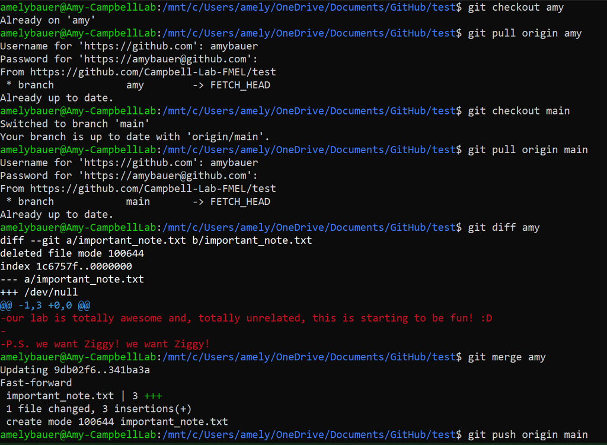